# Demo

Matteo Mazzamurro

2026-16-02

## Summary

This is a demo of the network analysis in the paper on Roman roads. It builds the ancient road networks (for the whole Empire and individual provinces), and computes the degree distribution by province.

Expected output: histogram of the degree distribution for a province of choice (default: “Achaia”).

## Preliminaries

### R version and packages

This document uses R version 4.4.3 (March, 2025).

To compute the total running time, we first run:

```r
start_time <- Sys.time()
```

The code relies on the following packages:

```r
required_packages_demo <- c(
  "tidyverse",
  "sf",
  "dplyr",
  "spatstat",
  "raster",
  "units",
  "igraph",
  "sfnetworks",
  "RColorBrewer",
  "colorRamps"
  )
```

*tidyverse* and *dplyr* offer a collection of methods for data analysis, that we use for data cleaning and visualisation. We use *sf* to read and handle shapefiles, *spatstat* for point processes and observation windows, *raster* to manage the coordinate projections, and *units* to ensure correct handling of distance units. We use *igraph* and *sfnetworks* to construct our network objects. *RColorBrewer* and *colorRamps* allow efficient management of colours.

One needs to install them if they are not installed yet.

```r
packages_to_install_demo <- required_packages_demo[!(required_packages_demo %in% installed.packages()[,"Package"])]
if(length(packages_to_install_demo)) install.packages(packages_to_install_demo)
```

Finally, one needs to load them.

```r
invisible(lapply(required_packages_demo, library, character.only = TRUE))
```

```
## spatstat.univar 3.1-3
```

```
## spatstat.geom 3.4-1
```

```
## spatstat.random 3.4-1
```

```
##
##
## spatstat.explore 3.4-3
```

```
## spatstat.model 3.3-6
```

```
## spatstat.linnet 3.2-6
##
## spatstat 3.3-3
## For an introduction to spatstat, type 'beginner'
```

```
## udunits database from C:/Users/qp24902/AppData/Local/R/win-library/4.4/units/share/udunits/udunits2.xml
```

If a package has been updated since the release of this code, using the newer version may cause issues. If this is the case, one can try to solve them by installing the specific versions of the packages by uncommenting and running the following code. Note, however, that these older versions of the packages may not be available for newer versions of R, in which case it will be necessary to switch to an older version of R to run the code (please refer to the cran.r website on how to do that: https://cran.r-project.org/index.html).

```r
## install devtools if not already installed
#if (!"devtools" %in% installed.packages()[,"Package"]) # install.packages("devtools")

# # load devtools
# library(devtools)

## install specific versions of the packages
# install_version("tidyverse", version = "2.0.0")
# install_version("dplyr", version = "1.1.4")
# install_version("sf", version = "1.0.13")
# install_version("spatstat", version = "3.0.7")
# install_version("raster", version = "3.6.26")
# install_version("units", version = "0.8.2")
# install_version("igraph", version = "1.4.3")
# install_version("sfnetworks", version = "0.6.3")
# install_version("RColorBrewer", version = "1.1.3")
# install_version("colorRamps", version = "2.3.1")

## load packages
# invisible(lapply(required_packages_demo, library, character.only = TRUE))
```

### Data

#### Data availability

- roads: export from itiner-e provided by the authors: de Soto, P. et al. (2025) A High-Resolution Dataset of Roads of the Roman Empire: Itiner-e static version 2024. Zenodo. https://doi.org/10.5281/zenodo.17122148
- provinces: file by published by The Ancient World Mapping Centre and corrected by Adam Pazout in 2023. https://github.com/AWMC/geodata/tree/master/Cultural-Data/political_shading/roman_empire_ce_200_province

#### Data import

First import the original data

```r
# roads (export from itiner-e)
roads_sf <- read_sf("./demo_data/roman_roads/roman_roads.shp")

# provinces
provinces_sf <- read_sf("./demo_data/roman_provinces_simple/roman_provinces.shp")
```

#### Data preprocessing

Ensure that all the data is in sf format, contains only valid columns, and is in the same coordinate reference system (epsg:4326)

```r
# roads
roads_sf$LENGTH_GEO <- ifelse(roads_sf$LENGTH_GEO>0, roads_sf$LENGTH_GEO, roads_sf$lengthGeo)
roads_sf <- roads_sf %>%
  dplyr::select(-Shape_Leng,-lengthGeo) %>%
  st_transform(crs=crs("epsg:4326")) %>%
  st_zm(drop = TRUE)

# provinces
provinces_sf <- provinces_sf %>%
  dplyr::select(province, Shape_Area, geometry) %>%
  st_transform(crs=crs("epsg:4326")) %>%
  st_zm(drop = TRUE)
```

Now, classify the roads and sites by provinces and create lists of shapefiles for the empire and individual provinces

```r
# extract names of geographical units
provinces <- provinces_sf$province
geographical_units_demo <-  c("Empire",provinces, "Italia")

# define "Italia" as a special study region
Italia_provinces <- provinces[str_detect(provinces,"Regio")]
Italia_sf <- provinces_sf %>%
  filter(province %in% Italia_provinces) %>%
  st_union()

# data by province
roads_with_provinces_sf <- st_join(roads_sf, provinces_sf, join = st_intersects)

# function to define named lists of shapefiles
by_province_l_f <- function(df){
  if ("province" %in% names(df)){
    df_by_province_l <- df %>%
      filter(!is.na(province)) %>%
      group_split(province) %>%
      setNames(provinces[provinces %in% df$province])
    return(df_by_province_l)
  } else {
    stop("The dataframe does not contain information on provinces")
  }
}

# define list of province shapefiles
roads_sf_provinces_l <- by_province_l_f(roads_with_provinces_sf)

# shapefiles for Italia
roads_sf_Italia <- roads_sf %>%
  filter(st_intersects(., Italia_sf, sparse = FALSE))
# initialise lists of shapefiles
roads_sf_demo_l <- list()

# populate lists
roads_sf_demo_l <- roads_sf_demo_l %>%
  append(list(Empire = roads_sf)) %>%       # add Empire
  append(roads_sf_provinces_l) %>%          # add provinces
  append(list(Italia= roads_sf_Italia))     # add Italia
```

## Ancient networks construction

Use the above shapefiels to build road networks by geographical unit

```r
# list of networks by province and in the entire empire
road_networks_demo_l <- lapply(roads_sf_demo_l,
                          as_sfnetwork,
                          directed = FALSE)

# assign time to traverse a road as as weight
road_networks_demo_l <- lapply(road_networks_demo_l, function(g){
  # extract info
  length <- E(g)$LENGTH_GEO              # in meters
  slope <- E(g)$Avg_Slope/100
  pace <- 3/5*exp(7/2*(abs(slope+0.05))) # Tobler's formula in seconds per meter
  weight = length*pace                   # in seconds

  # assign
  E(g)$weight <- weight
  return(g)
})
```

## Degree distribution

First, compute the degree sequence and degree distribution

```r
# compute the degree and assign as vertex attribute
road_networks_degree_l <- lapply(road_networks_demo_l,degree)

# add degree as vertex attribute
road_networks_demo_l <- lapply(road_networks_demo_l, function(g) {
  V(g)$degree <- degree(g)
  return(g)}
  )

# define list of dfs of degree distribution
road_networks_degree_distribution_df_demo_l <- lapply(
  road_networks_demo_l,
  function(g) {
    return(data.frame(
      degree = 0:max(V(g)$degree),
      fraction = degree_distribution(g)))
    }
  )
```

We use ggplot to create a barplot of the degree distribution

```r
# function to create a barplot of the degree distribution (print or save)
degree_distribution_barplot_demo_f <- function(gu,
                                          print = FALSE,
                                          save = FALSE){
  # define data
  data <- road_networks_degree_distribution_df_demo_l[[gu]]

  # define a plot title
  plot_title <- paste0("Degree distribution, ",gu)

  # define plot
  degree_distribution_barplot_gu <- ggplot(
    data = data,
    aes(degree,fraction)) +
    theme_minimal() +
        theme(panel.grid.major.x = element_blank(),
              panel.grid.minor.x = element_blank()) +
    # add the bar plot
    geom_bar(stat = "identity", fill = "skyblue") +
    #add labels
    labs(
      title = plot_title,
      x = "Degree",
      y = "Fraction of nodes") +
    scale_x_continuous(
      breaks = seq(min(data$degree),
                   max(data$degree),
                   by = 1))

  # define secondary outcomes
  if (print){
    print(degree_distribution_barplot_gu)
  }
  if (save){
    plot_name <- str_replace_all(paste0("degree distribution ",gu)," ","_")
    plot_path <- paste0("./demo_output/",plot_name,".pdf")
    ggsave(plot_path, degree_distribution_barplot_gu, width = 7, height = 5.5)
  }

  # return plot for future use
  # return(degree_distribution_barplot_gu)
}
```

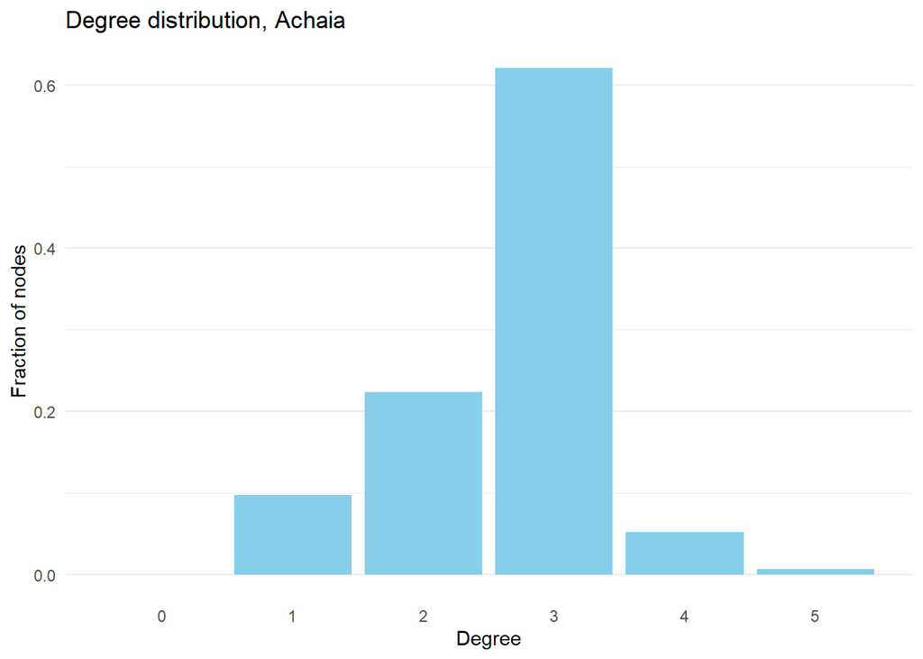

```r
# apply function
degree_distribution_barplot_demo_f("Achaia", print = TRUE, save = FALSE)
```

Bonus: to generate and save histograms for all provinces uncomment and run the following code

```r
## apply function (change print and/or save to TRUE)
#  degree_distribution_barplot_demo_l <- lapply(
#  geographical_units_demo,
#  degree_distribution_barplot_demo_f,
#  print = FALSE,
#  save = TRUE)
```

## Total runtime

```r
end_time <- Sys.time()
total_time <- end_time-start_time
print(total_time)
```

```
## Time difference of 24.44816 secs
```